# Practical Machine Learning Course Project

Palani

Sunday, April 10, 2016

# Objective

The goal of the project is to predict `the manner` in which the subjects did the `exercise`.

## Introduction

`Human activity` recognition is an area of increasing interest for many people that want to monitor their daily activities. Monitoring behaviour patterns with human activity recognition devices such as the Jawbone UP, Nike FuelBan, and Fitbit are helping people closely monitor their exercise routines while improving their health.

### Data Description

The dataset with 5 classes (sitting-down, standing-up, standing, walking, and sitting) collected on 8 hours of activities of 6 healthy subjects .More Details in [Human Activity Recognition](http://groupware.les.inf.puc-rio.br/har).

**importing data**

```r
training <- read.csv('E:/r/coursera/week4/pml-training.csv',na.strings=c('NA',''),stringsAsFactors = F)
training[training == "#DIV/0!" ] = NA
testing<-read.csv('E:/r/coursera/week4/pml-testing.csv',na.strings=c('NA',''),stringsAsFactors = F)
testing[testing == "#DIV/0!" ] = NA
str(training)
```

[output not shown]

[output not shown]

### Missing Percentage Column and Row wise

- choosing character values whose values are depicted as number.
- Converting back to numeric values

```r
train_char<-lapply(training,is.character)
names(train_char)[train_char==TRUE]
train_miss<-training[,-c(2,6,160)]
dim(train_miss)

i <- sapply(train_miss, is.character)
train_miss[i] <- lapply(train_miss[i], as.numeric)
str(train_miss)
```

###### Missing Percentage on column wise

101 columns have missing values more than `95%`

```r
hasMissing <- unlist(lapply(train_miss, function(x) any(is.na(x))))

names_missPer<-unlist(lapply(train_miss[,hasMissing],function(x){sum(is.na(x))/length(x)*100}))
```

###### Missing Percentage on row wise

98 Percentage of rows have more than `64 %` of columns missing

```r
miss_row<-apply((train_miss[,hasMissing]), 1, function(x) {sum(is.na(x))/dim(train_miss)[2]*100})
```

### Response distribution for the `classe` variable

Almost equal distributiion among all calsses execpt Classe `A`

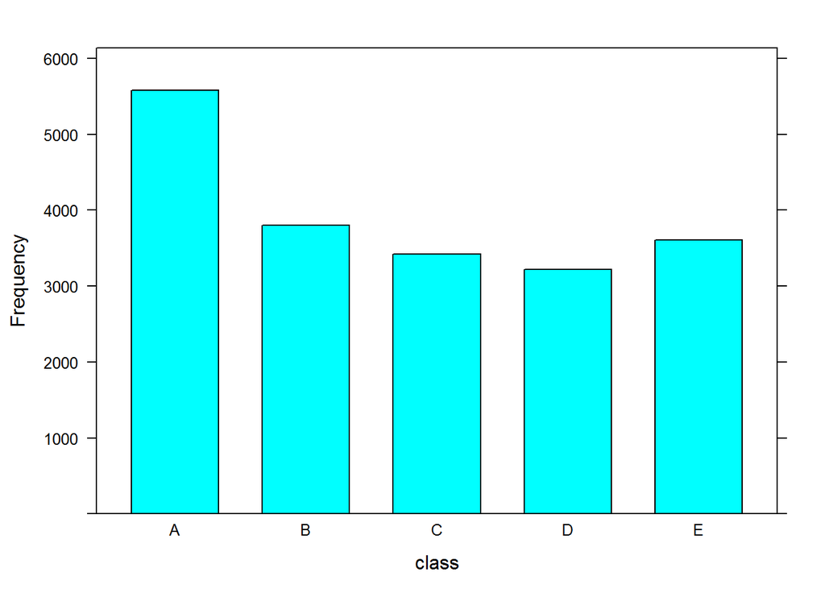

### classe variable description

- Sitting A
- Sitting down B
- Standing C
- Standing up D
- Walking E

Percentage of `classe` variable distribution

```
##
##         A         B         C         D         E
## 0.2843747 0.1935073 0.1743961 0.1638977 0.1838243
```

### Setting `predictor` and `response`

```r
Trainpredictors <- subset(training,select= -classe)
class <- training[,c('classe')]
Testpredictors<-subset(testing,select= -problem_id)
```

#### Removing near zero variance predictor

*Identify and remove NZV from both train and test dataset*

After removing near zero variance predictors, the dimension of `training` and `testing` datasets.

```
## [1] 19622   123
```

```
## [1]  20 123
```

### Missing value treatment

Columns having more than `95% Missing Values` are removed as they will not give any importance to the response

After removing Missing Values predictors, the dimension`of`training`and`testing` datasets.

```
## [1] 19622    58
```

```
## [1] 20 58
```

Removing id ,names and dates as it does not contribute to model performance.

```r
train<-train[,-(1:5)]
test<-test[,-(1:5)]
```

## Data Splitting

Using stratified random sampling based on response , data is split into `training` and `validation`

```r
set.seed(517)
trainingRows <- createDataPartition(class,p = .70,list= FALSE)
trainPredictors<- train[trainingRows,]
trainResponse <- class[trainingRows]
validPredictors <- train[-trainingRows,]
validResponse<-class[-trainingRows]
```

```
## [1] 13737    53
```

```
## [1] 13737
```

```
## [1] 5885   53
```

```
## [1] 5885
```

Checking the names of predictors in both training and test datasets

```r
names(test)==names(trainPredictors)
```

*Converting response variable from character to factor*

## Modeling

Choosing **Random Forest** classifier for classification.

```r
library(randomForest)
modFitB1 <- randomForest(trainResponse~.,data=trainPredictors)
prediction<-predict(modFitB1, validPredictors,type='class')
confusionMatrix(prediction, validResponse)$overall[1]
```

```
##  Accuracy
## 0.9976211
```

`OOB estimate of error rate`: 0.22%

## cross validation

To avoid `over-fitting` in random forest and optimize a `tuning parameter` that governs the number of features that are randomly chosen to grow each tree from the bootstrapped data. Typically, doing this via k-fold cross-validation, where k{5,10}, and choose the tuning parameter that minimizes test sample prediction error. In addition, growing a larger forest will improve predictive accuracy.

```r
crossval <- rfcv(trainPredictors,trainResponse)
```

*Finding the optimal Number of `variables vs error` using the plot*

```
## [1] 53 26 13  7  3  1
```

```
##          53          26          13           7           3           1
## 0.003203028 0.002911844 0.002475067 0.003494213 0.015869549 0.241683046
```

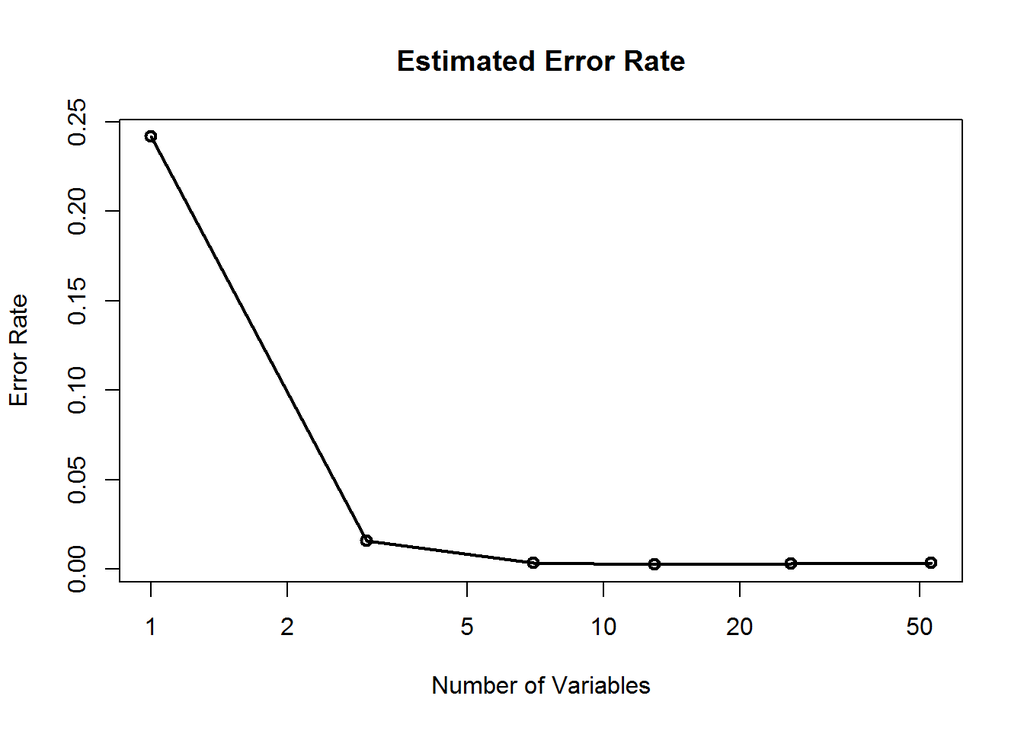

**predictors with Gini importance value**

```r
import <- importance(modFitB1, sort = TRUE)
```

**reordering predictors by importance**

```r
import <- import[order(import, decreasing=TRUE),,drop = FALSE]
```

**24 predictors listed by Gini importance**

```
##                      MeanDecreaseGini
## num_window                   956.9155
## roll_belt                    818.6740
## yaw_belt                     586.1630
## pitch_forearm                495.6918
## pitch_belt                   475.5440
## magnet_dumbbell_z            471.3981
## magnet_dumbbell_y            453.5580
## roll_forearm                 367.7684
## magnet_dumbbell_x            314.4451
## roll_dumbbell                280.1812
## accel_belt_z                 275.8630
## accel_dumbbell_y             271.0717
## magnet_belt_z                249.2378
## magnet_belt_y                245.3748
## accel_dumbbell_z             224.3947
## accel_forearm_x              204.0464
## roll_arm                     203.4145
## gyros_belt_z                 182.2413
## total_accel_dumbbell         181.6190
## accel_dumbbell_x             174.1083
## yaw_dumbbell                 171.0143
## magnet_arm_x                 166.5781
## magnet_forearm_z             165.6551
## magnet_belt_x                164.8422
```

*subset of 24 most important predictors*

```r
cleantrain24 <- trainPredictors[,rownames(import)[1:24]]
```

**random forest model fit with 24 most important predictors**

```r
modelFit24 <- randomForest(trainResponse ~., data=cleantrain24)
```

`OOB estimate` of error rate: 0.2%

Predicting with `validation` Predictors

```r
pred <- predict(modelFit24,validPredictors)

confusionMatrix(pred,validResponse)$overall[1]
```

```
##  Accuracy
## 0.9981308
```

`Out of sample errror` marginally improved over `in sample error`.

### Conclusion

We succeeded in producing a random forest model that predicted the form of different excercise positions being preformed by a participant. Our approximate outside sample error is at 0.19% which help generalise the model accurately. By implementing this model, we can classify the type of excercise the subjects do in matter of seconds.

### Predicting test dataset `quiz`

```r
pred <- predict(modelFit24,test,type='class')
```

http://palani2002.github.io/practicalmachinelearning